# TMDb Movie Dataset Investigation

- Introduction
- Data Wrangling
- Exploratory Data Analysis
- Conclusions

## Introduction

TMDb movie dataset contains information about 10,000 movies collected from The Movie Database (TMDb), including user ratings and revenue.

As a result of the investigation we'll try to gain information about different genres of the movies, rate their level of popularity, calculate their income and get more familiar with the features that are associated with different kinds of movies.

```python
import numpy as np
import pandas as pd
import matplotlib.pyplot as plt
import seaborn as sns

%matplotlib inline
```

## Data Wrangling

### General Properties

```python
# Loading data
df=pd.read_csv('tmdb-movies.csv')
```

```python
df.head()
```

|  | id | imdb_id | popularity | budget | revenue | original_title | cast | homepage | director | tagline | ... | overview | runtime | genres | production_companies | release_date | vote_count | vote_average | release_year | budget_adj | revenue_adj |
| --- | --- | --- | --- | --- | --- | --- | --- | --- | --- | --- | --- | --- | --- | --- | --- | --- | --- | --- | --- | --- | --- |
| 0 | 135397 | tt0369610 | 32.985763 | 150000000 | 1513528810 | Jurassic World | Chris Pratt\|Bryce Dallas Howard\|Irrfan Khan\|Vi... | http://www.jurassicworld.com/ | Colin Trevorrow | The park is open. | ... | Twenty-two years after the events of Jurassic ... | 124 | Action\|Adventure\|Science Fiction\|Thriller | Universal Studios\|Amblin Entertainment\|Legenda... | 6/9/15 | 5562 | 6.5 | 2015 | 1.379999e+08 | 1.392446e+09 |
| 1 | 76341 | tt1392190 | 28.419936 | 150000000 | 378436354 | Mad Max: Fury Road | Tom Hardy\|Charlize Theron\|Hugh Keays-Byrne\|Nic... | http://www.madmaxmovie.com/ | George Miller | What a Lovely Day. | ... | An apocalyptic story set in the furthest reach... | 120 | Action\|Adventure\|Science Fiction\|Thriller | Village Roadshow Pictures\|Kennedy Miller Produ... | 5/13/15 | 6185 | 7.1 | 2015 | 1.379999e+08 | 3.481613e+08 |
| 2 | 262500 | tt2908446 | 13.112507 | 110000000 | 295238201 | Insurgent | Shailene Woodley\|Theo James\|Kate Winslet\|Ansel... | http://www.thedivergentseries.movie/#insurgent | Robert Schwentke | One Choice Can Destroy You | ... | Beatrice Prior must confront her inner demons ... | 119 | Adventure\|Science Fiction\|Thriller | Summit Entertainment\|Mandeville Films\|Red Wago... | 3/18/15 | 2480 | 6.3 | 2015 | 1.012000e+08 | 2.716190e+08 |
| 3 | 140607 | tt2488496 | 11.173104 | 200000000 | 2068178225 | Star Wars: The Force Awakens | Harrison Ford\|Mark Hamill\|Carrie Fisher\|Adam D... | http://www.starwars.com/films/star-wars-episod... | J.J. Abrams | Every generation has a story. | ... | Thirty years after defeating the Galactic Empi... | 136 | Action\|Adventure\|Science Fiction\|Fantasy | Lucasfilm\|Truenorth Productions\|Bad Robot | 12/15/15 | 5292 | 7.5 | 2015 | 1.839999e+08 | 1.902723e+09 |
| 4 | 168259 | tt2820852 | 9.335014 | 190000000 | 1506249360 | Furious 7 | Vin Diesel\|Paul Walker\|Jason Statham\|Michelle ... | http://www.furious7.com/ | James Wan | Vengeance Hits Home | ... | Deckard Shaw seeks revenge against Dominic Tor... | 137 | Action\|Crime\|Thriller | Universal Pictures\|Original Film\|Media Rights ... | 4/1/15 | 2947 | 7.3 | 2015 | 1.747999e+08 | 1.385749e+09 |

5 rows × 21 columns

```python
df.shape
```

```
(10866, 21)
```

```python
df.info()
```

```
<class 'pandas.core.frame.DataFrame'>
RangeIndex: 10866 entries, 0 to 10865
Data columns (total 21 columns):
id                      10866 non-null int64
imdb_id                 10856 non-null object
popularity              10866 non-null float64
budget                  10866 non-null int64
revenue                 10866 non-null int64
original_title          10866 non-null object
cast                    10790 non-null object
homepage                2936 non-null object
director                10822 non-null object
tagline                 8042 non-null object
keywords                9373 non-null object
overview                10862 non-null object
runtime                 10866 non-null int64
genres                  10843 non-null object
production_companies    9836 non-null object
release_date            10866 non-null object
vote_count              10866 non-null int64
vote_average            10866 non-null float64
release_year            10866 non-null int64
budget_adj              10866 non-null float64
revenue_adj             10866 non-null float64
dtypes: float64(4), int64(6), object(11)
memory usage: 1.7+ MB
```

```python
df.describe()
```

|  | id | popularity | budget | revenue | runtime | vote_count | vote_average | release_year | budget_adj | revenue_adj |
| --- | --- | --- | --- | --- | --- | --- | --- | --- | --- | --- |
| count | 10866.000000 | 10866.000000 | 1.086600e+04 | 1.086600e+04 | 10866.000000 | 10866.000000 | 10866.000000 | 10866.000000 | 1.086600e+04 | 1.086600e+04 |
| mean | 66064.177434 | 0.646441 | 1.462570e+07 | 3.982332e+07 | 102.070863 | 217.389748 | 5.974922 | 2001.322658 | 1.755104e+07 | 5.136436e+07 |
| std | 92130.136561 | 1.000185 | 3.091321e+07 | 1.170035e+08 | 31.381405 | 575.619058 | 0.935142 | 12.812941 | 3.430616e+07 | 1.446325e+08 |
| min | 5.000000 | 0.000065 | 0.000000e+00 | 0.000000e+00 | 0.000000 | 10.000000 | 1.500000 | 1960.000000 | 0.000000e+00 | 0.000000e+00 |
| 25% | 10596.250000 | 0.207583 | 0.000000e+00 | 0.000000e+00 | 90.000000 | 17.000000 | 5.400000 | 1995.000000 | 0.000000e+00 | 0.000000e+00 |
| 50% | 20669.000000 | 0.383856 | 0.000000e+00 | 0.000000e+00 | 99.000000 | 38.000000 | 6.000000 | 2006.000000 | 0.000000e+00 | 0.000000e+00 |
| 75% | 75610.000000 | 0.713817 | 1.500000e+07 | 2.400000e+07 | 111.000000 | 145.750000 | 6.600000 | 2011.000000 | 2.085325e+07 | 3.369710e+07 |
| max | 417859.000000 | 32.985763 | 4.250000e+08 | 2.781506e+09 | 900.000000 | 9767.000000 | 9.200000 | 2015.000000 | 4.250000e+08 | 2.827124e+09 |

### Data Cleaning

```python
# Checking for duplicates
df.duplicated().sum()
```

```
1
```

```python
# Remove duplicates
df.drop_duplicates(inplace=True)
```

```python
df.duplicated().sum()
```

```
0
```

```python
# Droping columns which will not be used
df.drop(['homepage','tagline','keywords','production_companies'], axis=1, inplace=True)
```

```python
df.info()
```

```
<class 'pandas.core.frame.DataFrame'>
Int64Index: 10865 entries, 0 to 10865
Data columns (total 17 columns):
id                10865 non-null int64
imdb_id           10855 non-null object
popularity        10865 non-null float64
budget            10865 non-null int64
revenue           10865 non-null int64
original_title    10865 non-null object
cast              10789 non-null object
director          10821 non-null object
overview          10861 non-null object
runtime           10865 non-null int64
genres            10842 non-null object
release_date      10865 non-null object
vote_count        10865 non-null int64
vote_average      10865 non-null float64
release_year      10865 non-null int64
budget_adj        10865 non-null float64
revenue_adj       10865 non-null float64
dtypes: float64(4), int64(6), object(7)
memory usage: 1.5+ MB
```

```python
# Checking NAs in the director column for clues
df[df['director'].isnull()]
```

|  | id | imdb_id | popularity | budget | revenue | original_title | cast | director | overview | runtime | genres | release_date | vote_count | vote_average | release_year | budget_adj | revenue_adj |
| --- | --- | --- | --- | --- | --- | --- | --- | --- | --- | --- | --- | --- | --- | --- | --- | --- | --- |
| 532 | 320996 | tt4073952 | 0.126594 | 0 | 0 | Iliza Shlesinger: Freezing Hot | Iliza Shlesinger | NaN | Smart and brazen comedian Iliza Shlesinger sha... | 71 | Comedy | 1/23/15 | 14 | 6.6 | 2015 | 0.000000e+00 | 0.000000e+00 |
| 548 | 355131 | NaN | 0.108072 | 0 | 0 | Sense8: Creating the World | Tuppence Middleton\|Bae Doona \|Brian J. Smith\|A... | NaN | NaN | 25 | Documentary\|Science Fiction | 8/10/15 | 12 | 7.5 | 2015 | 0.000000e+00 | 0.000000e+00 |
| 556 | 321160 | tt3908634 | 0.100910 | 0 | 0 | With This Ring | Regina Hall\|Jill Scott\|Eve\|Brooklyn Sudano\|Dei... | NaN | After attending their friend Elise's (Sudano) ... | 105 | Comedy\|Romance | 1/24/15 | 14 | 6.5 | 2015 | 0.000000e+00 | 0.000000e+00 |
| 1032 | 259910 | tt3591568 | 0.291253 | 0 | 0 | Marvel Studios: Assembling a Universe | Robert Downey Jr.\|Chris Hemsworth\|Chris Evans\|... | NaN | A look at the story behind Marvel Studios and ... | 43 | TV Movie\|Documentary | 3/18/14 | 32 | 6.3 | 2014 | 0.000000e+00 | 0.000000e+00 |
| 1054 | 253675 | tt3711030 | 0.269468 | 0 | 0 | Unlocking Sherlock | Benedict Cumberbatch\|Martin Freeman\|Steven Mof... | NaN | Explore how writers Steven Moffat and Mark Gat... | 60 | TV Movie\|Documentary | 1/19/14 | 11 | 7.2 | 2014 | 0.000000e+00 | 0.000000e+00 |
| 1203 | 256561 | tt3203290 | 0.119891 | 150000 | 0 | Free to Play | Benedict Lim\|Danil Ishutin\|Clinton Loomis | NaN | Follow three professional video game players a... | 75 | Documentary | 3/19/14 | 40 | 7.0 | 2014 | 1.381637e+05 | 0.000000e+00 |
| 1241 | 296370 | tt3024964 | 0.135376 | 0 | 0 | Dance-Off | Kathryn McCormick\|Shane Harper\|Finola Hughes\|C... | NaN | DANCE-OFF is a tongue-in-cheek family comedy s... | 0 | Romance\|Music\|Comedy | 1/1/14 | 18 | 5.7 | 2014 | 0.000000e+00 | 0.000000e+00 |
| 1288 | 301235 | tt4217172 | 0.038364 | 0 | 0 | Top Gear: The Perfect Road Trip 2 | Jeremy Clarkson\|Richard Hammond | NaN | In 2013 Jeremy Clarkson and Richard Hammond em... | 94 | Documentary | 11/17/14 | 12 | 6.8 | 2014 | 0.000000e+00 | 0.000000e+00 |
| 1852 | 133365 | tt1127205 | 0.256703 | 0 | 0 | The Diary of Anne Frank | Ellie Kendrick\|Kate Ashfield\|Geoff Breton\|Feli... | NaN | Called the most accurate adaptation of Anne Fr... | 100 | Drama | 1/9/09 | 19 | 7.5 | 2009 | 0.000000e+00 | 0.000000e+00 |
| 1872 | 26379 | tt1532957 | 0.091395 | 3250000 | 0 | Paa | Amitabh Bachchan\|Abhishek Bachchan\|Vidya Balan... | NaN | He suffers from a progeria like syndrome. Ment... | 133 | Drama\|Family\|Foreign | 12/4/09 | 11 | 6.1 | 2009 | 3.303301e+06 | 0.000000e+00 |
| 1895 | 281979 | tt1413314 | 0.056777 | 0 | 0 | Doctor Who: The Waters of Mars | David Tennant | NaN | The Doctor joins forces with his oldest compan... | 62 | Science Fiction\|Adventure\|Family | 12/19/09 | 25 | 8.0 | 2009 | 0.000000e+00 | 0.000000e+00 |
| 2221 | 48832 | tt1707823 | 0.281852 | 0 | 0 | Scott Pilgrim vs. the Animation | Michael Cera\|Alison Pill\|Georgette Perna\|Mae W... | NaN | Scott Pilgrim vs. The Animation is an animated... | 4 | TV Movie\|Animation\|Adventure | 8/10/10 | 19 | 7.7 | 2010 | 0.000000e+00 | 0.000000e+00 |
| 2286 | 47911 | tt1747960 | 0.207234 | 0 | 0 | Bo Burnham: Words, Words, Words | Bo Burnham | NaN | Bo Burnham is back with a new one-man show ful... | 63 | Comedy | 10/19/10 | 13 | 6.5 | 2010 | 0.000000e+00 | 0.000000e+00 |
| 2290 | 51823 | tt1663193 | 0.203502 | 0 | 0 | Across the Line: The Exodus of Charlie Wright | Aidan Quinn\|Andy García\|Mario Van Peebles\|Dan... | NaN | The story centers on Charlie, a Los Angeles bi... | 94 | Drama\|Action\|Thriller\|Crime | 12/28/10 | 11 | 6.0 | 2010 | 0.000000e+00 | 0.000000e+00 |
| 2315 | 48373 | tt1274296 | 0.171615 | 0 | 0 | Listen to Your Heart | Alexia Rasmussen\|Kent Moran\|Cybill Shepherd\|Sh... | NaN | Danny Foster doesn't have much: an apartment a... | 0 | Drama\|Music\|Romance | 8/14/10 | 29 | 7.3 | 2010 | 0.000000e+00 | 0.000000e+00 |
| 2318 | 34134 | tt1610301 | 0.170408 | 0 | 0 | Barbie in A Mermaid Tale | Kelly Sheridan\|Kathleen Barr\|Nakia Burrise\|Gar... | NaN | Barbie stars as Merliah, a surfing champion fr... | 75 | Animation\|Family\|Fantasy | 1/26/10 | 35 | 6.3 | 2010 | 0.000000e+00 | 0.000000e+00 |
| 2376 | 315620 | tt1672218 | 0.068411 | 0 | 0 | Doctor Who: A Christmas Carol | Matt Smith\|Karen Gillan\|Arthur Darvill\|Michael... | NaN | Amy Pond and Rory Williams are trapped on a cr... | 62 | NaN | 12/25/10 | 11 | 7.7 | 2010 | 0.000000e+00 | 0.000000e+00 |
| 2397 | 241829 | tt1805454 | 0.033048 | 0 | 0 | The Making of The Walking Dead | NaN | NaN | The Making of the TV Series The Walking Dead | 30 | Documentary | 7/31/10 | 42 | 8.4 | 2010 | 0.000000e+00 | 0.000000e+00 |
| 2401 | 45644 | NaN | 0.067753 | 0 | 0 | Opeth: In Live Concert At The Royal Albert Hall | Mikael Åkerfeldt\|Martin "Axe" Axenrot\|Martin ... | NaN | As part of the ongoing celebration of their 20... | 163 | Music | 9/21/10 | 10 | 8.6 | 2010 | 0.000000e+00 | 0.000000e+00 |
| 2403 | 72013 | tt1587157 | 0.067620 | 0 | 0 | Yu-Gi-Oh! 3D: Bonds Beyond Time | Greg Abbey\|Dan Green\|Matthew Charles\|Sean Sche... | NaN | After falling through a time-slip, Yusei Fudo ... | 60 | Animation\|Fantasy | 1/23/10 | 10 | 6.0 | 2010 | 0.000000e+00 | 0.000000e+00 |
| 3171 | 17171 | tt1201984 | 0.019819 | 0 | 0 | The Assassination of Jesse James: Death Of An ... | Ted Levine\|Casey Affleck\|Brad Pitt\|Mary-Louise... | NaN | Explores the true story of the notorious Jesse... | 32 | Documentary | 1/1/08 | 20 | 6.8 | 2008 | 0.000000e+00 | 0.000000e+00 |
| 3224 | 20313 | tt1270491 | 0.224721 | 0 | 0 | John Mayer: Where the Light Is Live in Los Ang... | John Mayer\|Steve Jordan\|Pino Palladino\|David R... | NaN | Where The Light Is: John Mayer Live in Los Ang... | 164 | Music | 7/1/08 | 16 | 8.5 | 2008 | 0.000000e+00 | 0.000000e+00 |
| 3276 | 15467 | tt1105733 | 0.147657 | 4180000 | 11000000 | Kismat Konnection | Shahid Kapoor\|Vidya Balan\|Juhi Chawla\|Om Puri\|... | NaN | This is a story about an architect Raj Malhotr... | 153 | Drama\|Comedy\|Romance\|Foreign | 7/18/08 | 11 | 5.8 | 2008 | 4.233448e+06 | 1.114065e+07 |
| 3285 | 36131 | tt1286750 | 0.136883 | 0 | 0 | Tropic Thunder: Rain of Madness | Justin Theroux\|Jack Black\|Steve Coogan\|Robert ... | NaN | A behind-the-scenes mockumentary of Tropic Thu... | 30 | Action\|Comedy | 8/26/08 | 12 | 6.9 | 2008 | 0.000000e+00 | 0.000000e+00 |
| 3357 | 32836 | tt1254947 | 0.042517 | 0 | 0 | Bill Burr: Why Do I Do This? | Bill Burr | NaN | One of America's fastest-rising comedians, Bil... | 55 | Comedy | 9/23/08 | 10 | 8.0 | 2008 | 0.000000e+00 | 0.000000e+00 |
| 3365 | 22258 | tt1321823 | 0.002475 | 0 | 0 | Foo Fighters: Live at Wembley Stadium | Dave Grohl\|Nate Mendel\|Chris Shiflett\|Pat Smea... | NaN | Foo Fighters captured over their two sold-out ... | 120 | Music | 8/25/08 | 10 | 8.4 | 2008 | 0.000000e+00 | 0.000000e+00 |
| 3369 | 77974 | tt2014400 | 0.001682 | 0 | 0 | Wizards On Deck With Hannah Montana | NaN | NaN | Three Disney Channel shows come together in "W... | 68 | Family | 2/11/08 | 14 | 6.1 | 2008 | 0.000000e+00 | 0.000000e+00 |
| 3910 | 79976 | tt2096615 | 0.002006 | 0 | 0 | Steve Jobs: One Last Thing | NaN | NaN | Through interviews with colleagues and others ... | 60 | Documentary | 11/2/11 | 11 | 6.6 | 2011 | 0.000000e+00 | 0.000000e+00 |
| 4679 | 91342 | tt2197823 | 0.421746 | 0 | 0 | Barbie in A Mermaid Tale 2 | Nakia Burrise\|Gary Chalk | NaN | Surf's up for Barbie as she returns as Merliah... | 74 | Animation\|Family | 2/23/12 | 22 | 6.0 | 2012 | 0.000000e+00 | 0.000000e+00 |
| 4797 | 369145 | NaN | 0.167501 | 0 | 0 | Doctor Who: The Snowmen | Matt Smith\|Jenna Coleman\|Richard E. Grant\|Ian ... | NaN | Christmas Eve, 1892, and the falling snow is t... | 60 | NaN | 12/25/12 | 10 | 7.8 | 2012 | 0.000000e+00 | 0.000000e+00 |
| 4872 | 269177 | NaN | 0.090552 | 0 | 0 | Party Bercy | Florence Foresti | NaN | Florence Foresti is offered Bercy tribute to a... | 120 | Comedy | 9/23/12 | 15 | 6.4 | 2012 | 0.000000e+00 | 0.000000e+00 |
| 4939 | 168219 | tt2167393 | 0.003183 | 0 | 0 | The Men Who Built America | NaN | NaN | John D. Rockefeller, Cornelius Vanderbilt, And... | 360 | Documentary\|History | 10/16/12 | 11 | 5.3 | 2012 | 0.000000e+00 | 0.000000e+00 |
| 5413 | 20378 | tt0163986 | 0.324270 | 0 | 0 | The Brave Little Toaster to the Rescue | NaN | NaN | Those fun-loving eletrical appliances from the... | 74 | Animation\|Comedy\|Family | 11/1/97 | 11 | 7.0 | 1997 | 0.000000e+00 | 0.000000e+00 |
| 5866 | 246569 | tt2934844 | 0.211825 | 5000000 | 0 | Jinxed | Ciara Bravo\|Jack Griffo\|Jacob Bertrand\|Elena K... | NaN | Meet the Murphys, a family with never ending b... | 75 | Family\|Fantasy\|Comedy | 11/29/13 | 19 | 7.0 | 2013 | 4.680167e+06 | 0.000000e+00 |
| 5915 | 284019 | tt2283584 | 0.168210 | 0 | 0 | Phineas and Ferb: Mission Marvel | Vincent Martella\|Thomas Brodie-Sangster\|Ashley... | NaN | When Dr. Doofenshmirtz's latest invention caus... | 44 | Action\|Adventure\|Science Fiction | 8/16/13 | 13 | 5.9 | 2013 | 0.000000e+00 | 0.000000e+00 |
| 5972 | 238234 | tt3258142 | 0.165605 | 0 | 0 | Top Gear: The Perfect Road Trip | Jeremy Clarkson\|Richard Hammond | NaN | The aim: to select the ideal mode of transport... | 84 | TV Movie\|Action\|Adventure\|Documentary | 11/17/13 | 35 | 7.6 | 2013 | 0.000000e+00 | 0.000000e+00 |
| 6033 | 238185 | tt3397430 | 0.048587 | 0 | 0 | Russell Brand: Messiah Complex | Russell Brand | NaN | Recorded live at Hammersmith Apollo, Russell q... | 99 | Comedy | 11/25/13 | 12 | 6.8 | 2013 | 0.000000e+00 | 0.000000e+00 |
| 6181 | 18729 | tt0088583 | 0.000065 | 0 | 0 | North and South, Book I | Patrick Swayze\|Philip Casnoff\|Kirstie Alley\|Ge... | NaN | Two friends, one northern and one southern, st... | 561 | Drama\|History\|Western | 11/3/85 | 17 | 6.0 | 1985 | 0.000000e+00 | 0.000000e+00 |
| 7579 | 58432 | tt0484273 | 0.443952 | 0 | 0 | La hora fría | Silke\|Omar Muñoz\|Pepo Oliva\|Carola Manzanares... | NaN | The eight years boy Jesús has been living in ... | 92 | Horror\|Thriller\|Science Fiction\|Mystery\|Foreign | 9/14/07 | 10 | 4.9 | 2007 | 0.000000e+00 | 0.000000e+00 |
| 7767 | 282758 | tt0827573 | 0.126603 | 0 | 0 | Doctor Who: The Runaway Bride | David Tennant\|Catherine Tate | NaN | A young bride in the midst of her wedding find... | 60 | Science Fiction\|TV Movie | 7/6/07 | 18 | 7.6 | 2007 | 0.000000e+00 | 0.000000e+00 |
| 7814 | 25565 | tt1236486 | 0.040311 | 0 | 0 | Transformers: Beginnings | Peter Cullen\|Frank Welker\|Mark Ryan\|Patrick Ha... | NaN | On their home planet of Cybertron, the Autobot... | 22 | Animation\|Action\|Thriller\|Science Fiction | 10/16/07 | 34 | 5.8 | 2007 | 0.000000e+00 | 0.000000e+00 |
| 9593 | 46188 | tt0220698 | 0.001662 | 0 | 0 | Peter Pan | NaN | NaN | This animated fairy tale for kids tells the cl... | 52 | Action\|Adventure\|Animation\|Family\|Fantasy | 1/1/88 | 28 | 6.6 | 1988 | 0.000000e+00 | 0.000000e+00 |
| 10386 | 225804 | tt1028555 | 0.118854 | 0 | 0 | The Making of 'The Nightmare Before Christmas' | Mike Belzer\|Tim Burton\|Bonita DeCarlo\|Greg Dyk... | NaN | The Making of Tim Burton and Henry Selick's 19... | 25 | Documentary | 10/3/93 | 15 | 7.5 | 1993 | 0.000000e+00 | 0.000000e+00 |
| 10426 | 34038 | tt0061937 | 0.114034 | 0 | 0 | Magical Mystery Tour | John Lennon\|Paul McCartney\|George Harrison\|Rin... | NaN | A typically Beatlesque film originally produce... | 55 | Music | 12/25/67 | 15 | 5.8 | 1967 | 0.000000e+00 | 0.000000e+00 |

```python
# We didn't find any clues for NAs, so we'll just drop them
df.dropna(inplace=True)
```

```python
df.info()
```

```
<class 'pandas.core.frame.DataFrame'>
Int64Index: 10724 entries, 0 to 10865
Data columns (total 17 columns):
id                10724 non-null int64
imdb_id           10724 non-null object
popularity        10724 non-null float64
budget            10724 non-null int64
revenue           10724 non-null int64
original_title    10724 non-null object
cast              10724 non-null object
director          10724 non-null object
overview          10724 non-null object
runtime           10724 non-null int64
genres            10724 non-null object
release_date      10724 non-null object
vote_count        10724 non-null int64
vote_average      10724 non-null float64
release_year      10724 non-null int64
budget_adj        10724 non-null float64
revenue_adj       10724 non-null float64
dtypes: float64(4), int64(6), object(7)
memory usage: 1.5+ MB
```

```python
# Fixing datatypes
df['release_date']=pd.to_datetime(df['release_date'])
```

```python
df.head()
```

|  | id | imdb_id | popularity | budget | revenue | original_title | cast | director | overview | runtime | genres | release_date | vote_count | vote_average | release_year | budget_adj | revenue_adj |
| --- | --- | --- | --- | --- | --- | --- | --- | --- | --- | --- | --- | --- | --- | --- | --- | --- | --- |
| 0 | 135397 | tt0369610 | 32.985763 | 150000000 | 1513528810 | Jurassic World | Chris Pratt\|Bryce Dallas Howard\|Irrfan Khan\|Vi... | Colin Trevorrow | Twenty-two years after the events of Jurassic ... | 124 | Action\|Adventure\|Science Fiction\|Thriller | 2015-06-09 | 5562 | 6.5 | 2015 | 1.379999e+08 | 1.392446e+09 |
| 1 | 76341 | tt1392190 | 28.419936 | 150000000 | 378436354 | Mad Max: Fury Road | Tom Hardy\|Charlize Theron\|Hugh Keays-Byrne\|Nic... | George Miller | An apocalyptic story set in the furthest reach... | 120 | Action\|Adventure\|Science Fiction\|Thriller | 2015-05-13 | 6185 | 7.1 | 2015 | 1.379999e+08 | 3.481613e+08 |
| 2 | 262500 | tt2908446 | 13.112507 | 110000000 | 295238201 | Insurgent | Shailene Woodley\|Theo James\|Kate Winslet\|Ansel... | Robert Schwentke | Beatrice Prior must confront her inner demons ... | 119 | Adventure\|Science Fiction\|Thriller | 2015-03-18 | 2480 | 6.3 | 2015 | 1.012000e+08 | 2.716190e+08 |
| 3 | 140607 | tt2488496 | 11.173104 | 200000000 | 2068178225 | Star Wars: The Force Awakens | Harrison Ford\|Mark Hamill\|Carrie Fisher\|Adam D... | J.J. Abrams | Thirty years after defeating the Galactic Empi... | 136 | Action\|Adventure\|Science Fiction\|Fantasy | 2015-12-15 | 5292 | 7.5 | 2015 | 1.839999e+08 | 1.902723e+09 |
| 4 | 168259 | tt2820852 | 9.335014 | 190000000 | 1506249360 | Furious 7 | Vin Diesel\|Paul Walker\|Jason Statham\|Michelle ... | James Wan | Deckard Shaw seeks revenge against Dominic Tor... | 137 | Action\|Crime\|Thriller | 2015-04-01 | 2947 | 7.3 | 2015 | 1.747999e+08 | 1.385749e+09 |

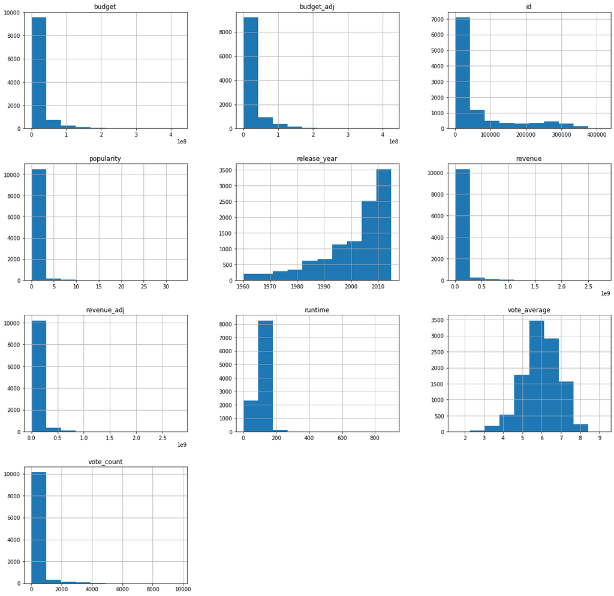

```python
df.hist(figsize=(20,20));
```

```python
# For further investigation we need to work with genres column, let's check how many unique values it has
df.genres.value_counts()
```

```
Drama                                                710
Comedy                                               706
Drama|Romance                                        289
Comedy|Drama                                         280
Documentary                                          274
Comedy|Romance                                       267
Horror|Thriller                                      259
Horror                                               253
Comedy|Drama|Romance                                 222
Drama|Thriller                                       138
Comedy|Family                                        102
Action|Thriller                                      101
Thriller                                              93
Drama|Comedy                                          92
Animation|Family                                      84
Crime|Drama|Thriller                                  81
Crime|Drama                                           74
Comedy|Horror                                         72
Drama|Comedy|Romance                                  64
Action                                                63
Action|Comedy                                         61
Drama|History                                         58
Action|Crime|Drama|Thriller                           54
Drama|Horror|Thriller                                 53
Action|Crime|Thriller                                 52
Horror|Science Fiction                                52
Horror|Mystery|Thriller                               51
Comedy|Crime                                          50
Drama|Music                                           49
Documentary|Music                                     49
                                                    ...
Action|Fantasy|Comedy|Horror|Mystery                   1
Adventure|Family|Romance                               1
Action|Adventure|Animation|Comedy|Drama                1
Action|Science Fiction|Drama                           1
Mystery|Thriller|Crime|Horror                          1
Drama|Horror|Thriller|TV Movie                         1
History|Drama|Thriller|War                             1
Thriller|Comedy|Action                                 1
Drama|Western|War|Romance                              1
Adventure|Fantasy|Mystery                              1
Action|Adventure|Drama|Thriller|War                    1
Animation|Comedy|Science Fiction|Fantasy               1
Documentary|Drama|History                              1
Action|Comedy|Romance|Science Fiction|Thriller         1
Science Fiction|Animation|Family|Comedy|Adventure      1
Drama|Family|Music                                     1
Horror|Drama|Romance|Thriller                          1
Fantasy|Horror|Thriller|Science Fiction|Mystery        1
Drama|History|Horror                                   1
Adventure|Action|Comedy|Western                        1
Adventure|Fantasy|Horror|Science Fiction               1
Science Fiction|Comedy|Family|Romance                  1
Adventure|Animation|Romance                            1
Music|Family|Drama                                     1
Drama|History|Western                                  1
War|Drama|History|Thriller                             1
Family|Animation|Drama                                 1
Foreign|Horror|Mystery                                 1
Animation|Science Fiction|Fantasy|Adventure            1
Drama|Crime|Mystery|Comedy                             1
Name: genres, Length: 2020, dtype: int64
```

```python
# Let's assume that is the first mentioned genre in a row is the main one, so we can make our data a bit cleaner
df['genres']=df['genres'].apply(lambda x:x.split("|")[0])
df.genres.value_counts()
```

```
Drama              2443
Comedy             2312
Action             1584
Horror              914
Adventure           584
Thriller            491
Documentary         387
Crime               380
Animation           374
Fantasy             271
Science Fiction     211
Romance             185
Family              142
Mystery             125
Music                95
TV Movie             74
War                  58
History              44
Western              42
Foreign               8
Name: genres, dtype: int64
```